# OzCBI fire severity using Sentinel satellite data

Densmore. V, Fontaine. J and van Dongen. R

15 May 2021

**Field and imagery data**

The data was checked and outliers were identified and removed from the analysis.

For each fire in the analysis Landsat satellite imagery was acquired spanning the start and end burn dates. Imagery was checked for cloud and only those where the fire area was cloud free were retained.

**Create variables**

From the Landsat time series and fire start and end dates a range of variables can be created. In this version the following variables have been used.

- preNBR - nbr value of the image prior to the burn date;
- preNDVI - ndvi value of the image prior to the burn date;
- preB4 - Band 4 value of the image prior to the burn date:
- prei35 - the i35 index value of the image prior to the burn date;
- preNDWI - the ndwi index value of the image prior to the burn date;
- dNBRmax - the maximum difference between the pre burn nbr and all nbr values until the fire end;
- dNDVImax - the maximum difference between the pre burn ndvi and all ndvi values until the fire end;
- dB4max - the maximum difference between the pre burn B4 and all B4 values until the fire end;
- di35max - the maximum difference between the pre burn i35 and all i35 values until the fire end;
- dNDWImax - the maximum difference between the pre burn ndwi and all ndwi values until the fire end; and
- RBRmax - relativised burn ratio using the maximum difference between the pre burn nbr and all nbr values until the fire end.

others can be added

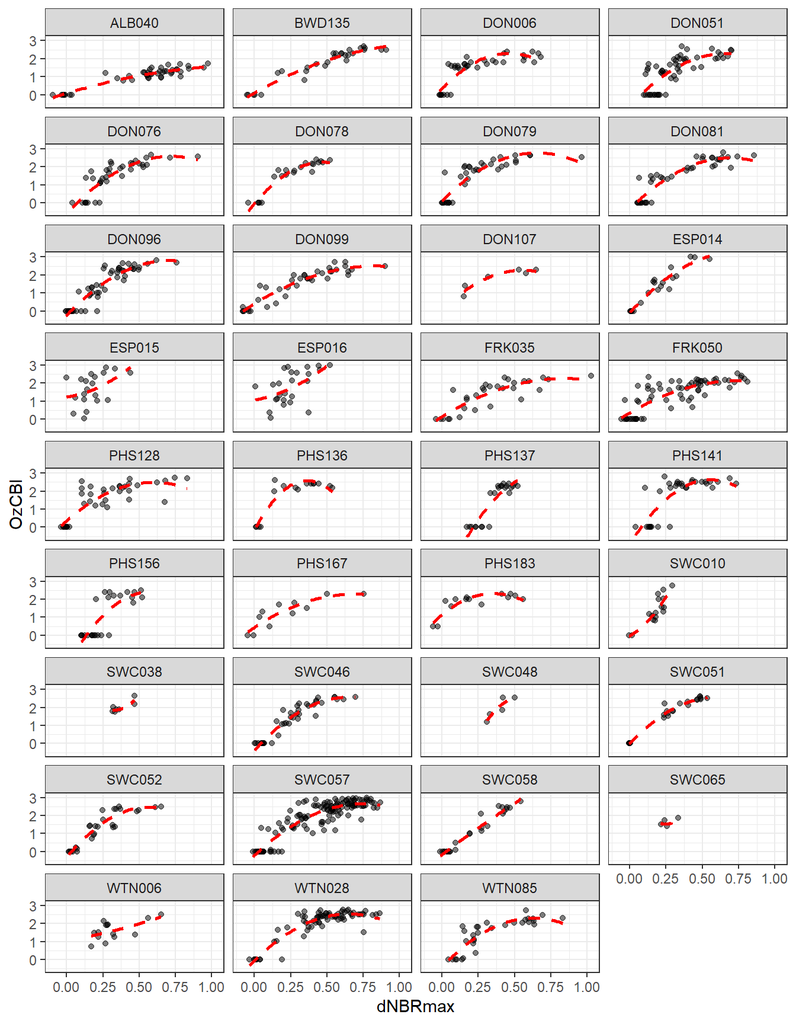

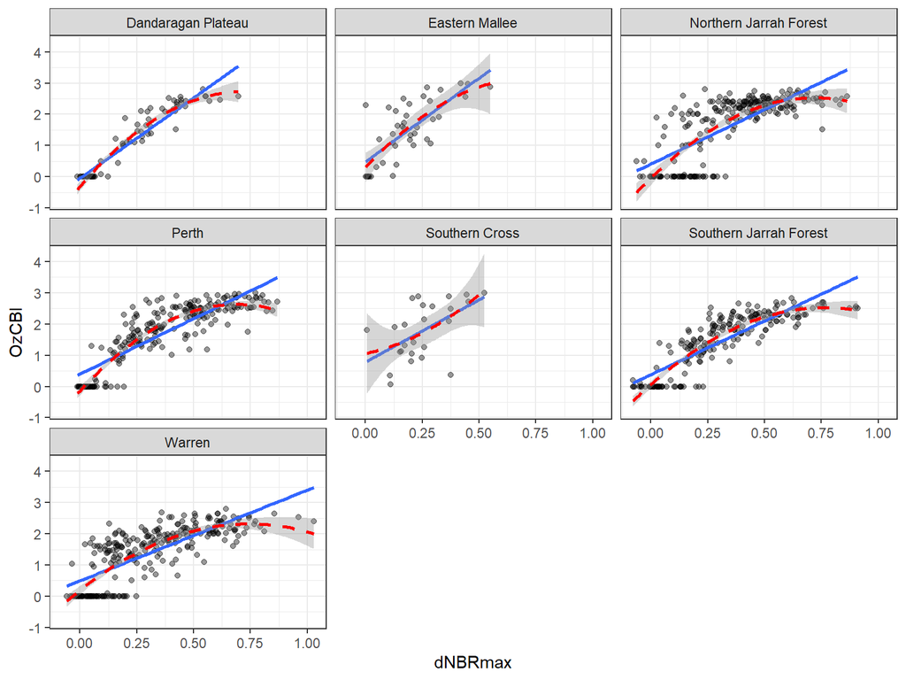

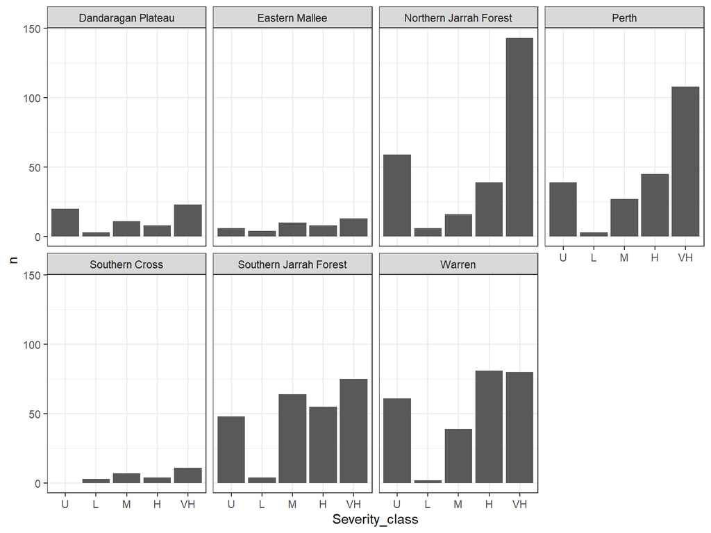

Field points from the above fires were classified in terms of fire severity and grouped by ibra region.

Prediction accuracy of burn severity class within ibra regions, using Sentinel bands.

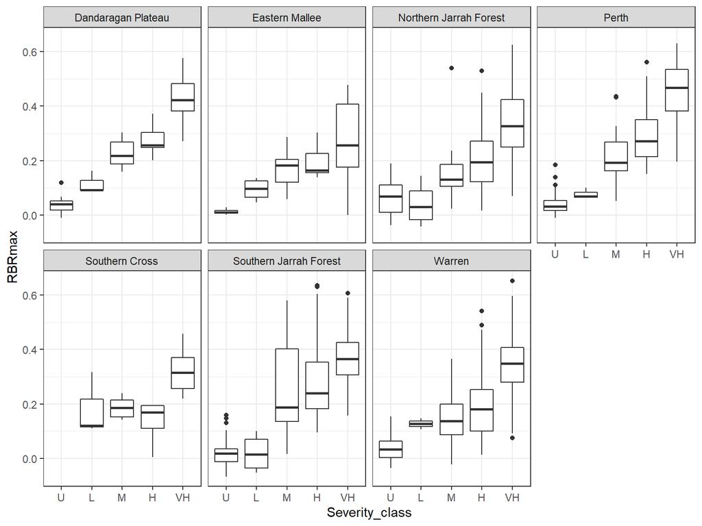

Table 6. Overall classificaion accuracy from cross-validation

| Ibra | Random Forest | Weighted | Decision tree (dNBR) | Quadratic (dNBR) |
| --- | --- | --- | --- | --- |
| Dandaragan Plateau | 69.2 | 67.7 | 69.2 | 44.6 |
| Northern Jarrah Forest | 68.4 | 61.3 | 70.2 | 47.6 |
| Perth | 71.2 | 67.1 | 71.2 | 58.6 |
| Southern Jarrah Forest | 66.2 | 66.7 | 65.2 | 54.7 |
| Warren | 58.9 | 58.2 | 60.5 | 41.1 |

Table 6. Overall classificaion accuracy within one class from cross-validation

| Ibra | Random Forest | Weighted | Decision tree (dNBR) | Quadratic (dNBR) |
| --- | --- | --- | --- | --- |
| Dandaragan Plateau | 92.3 | 96.9 | 84.6 | 98.5 |
| Northern Jarrah Forest | 88.0 | 88.4 | 80.9 | 81.3 |
| Perth | 92.3 | 90.1 | 93.7 | 95.5 |
| Southern Jarrah Forest | 92.5 | 95.0 | 91.5 | 93.5 |
| Warren | 87.8 | 85.9 | 88.2 | 84.0 |

Southern Jarrah Forest

Table 5. Error matrix for fires within the Southern Jarrah Forest

| Reference | U | L | M | H | VH |
| --- | --- | --- | --- | --- | --- |
| U | 30 | 1 | 9 | 0 | 0 |
| L | 3 | 0 | 0 | 1 | 0 |
| M | 4 | 0 | 20 | 12 | 1 |
| H | 0 | 0 | 12 | 22 | 11 |
| VH | 0 | 0 | 0 | 14 | 61 |

Warren

Table 4. Error matrix for fires within the Warren Ibra

| Reference | U | L | M | H | VH |
| --- | --- | --- | --- | --- | --- |
| U | 47 | 0 | 4 | 10 | 0 |
| L | 1 | 0 | 0 | 1 | 0 |
| M | 3 | 0 | 7 | 25 | 4 |
| H | 9 | 0 | 13 | 45 | 14 |
| VH | 0 | 0 | 1 | 23 | 56 |

Northern Jarrah Forest

Table 4. Error matrix for fires within the Northern Jarrah Forest Ibra

| Reference | U | L | M | H | VH |
| --- | --- | --- | --- | --- | --- |
| U | 43 | 1 | 1 | 1 | 5 |
| L | 4 | 0 | 0 | 1 | 0 |
| M | 5 | 0 | 0 | 4 | 2 |
| H | 8 | 0 | 0 | 5 | 19 |
| VH | 4 | 0 | 0 | 16 | 106 |

Perth

Table 4. Error matrix for fires within the Perth Ibra

| Reference | U | L | M | H | VH |
| --- | --- | --- | --- | --- | --- |
| U | 32 | 2 | 5 | 0 | 0 |
| L | 2 | 0 | 1 | 0 | 0 |
| M | 3 | 0 | 11 | 8 | 5 |
| H | 3 | 0 | 9 | 18 | 15 |
| VH | 0 | 0 | 1 | 10 | 97 |

Dandaragan

Table 4. Error matrix for fires within the Dandaragan Ibra

| Reference | U | L | M | H | VH |
| --- | --- | --- | --- | --- | --- |
| U | 20 | 0 | 0 | 0 | 0 |
| L | 2 | 0 | 1 | 0 | 0 |
| M | 1 | 2 | 5 | 2 | 1 |
| H | 0 | 0 | 6 | 0 | 2 |
| VH | 0 | 0 | 3 | 0 | 20 |

Version date: 2021-05-26